# TERRE GRS: Epigenome-wide asssociation analysis

The manuscript “A Parkinson’s disease genetic risk score associates with blood DNAm on chromosome 17” explores how a genetic risk score (GRS) for Parkinson’s disease (PD) associates with blood DNA methylation in the TERRE study of French agricultural workers, and evaluates GRS associations with DNAm in each sex as well as their sensitivity to non-genetic factors. This was originally spearheaded by Will Casazza and was posted as a pre-print on medRxiv in 2023. The current revision (2024, led by Sam Schaffner) aims to address previous reviewer feedback and prepare the manuscript for re-submission.

In this script, EWAS is conducted to identify DNAm patterns associated with the GRS in the cross-sex and sex-stratified samples in TERRE. The models are adjusted for batch, cell type, and disease status. Results will be compared with the previous models (adjusted for 10 DNAm PCs).

Last updated June 19, 2024 by Samantha Schaffner: Adding sex- and disease-stratified EWAS results

Based on code by Will Casazza

### Loading in and preparing data

```r
meta <- read.csv("~/PD_GRS/meta_geno_DNAm_PCs.csv")

# DNAm data (2022, most recent QC'ed, same as npj PD 2024 article)
load("~/SHARE_DECIPHER/processed_DNAm_data/2022/TERRE_processed_2022/1-TERRE_RG_filtered.RData")
mvals <- getM(PD_RG_filtered)
```

# Association analysis

## EWAS model checks

Prior to looking at results, I’ll assess whether the new EWAS model seems appropriate using three measures:

*1. Variance inflation factor*: The variance inflation factor (VIF) can be used to detect collinearity. Higher VIF values indicate a greater degree of collinearity. Typically VIF < 5 is considered acceptable.

*2. Q-Q plot of nominal p-values*: If the variable of interest does not affect global DNAm, p-values should distribute close to the center line on a normal Q-Q plot, with some deviation at the tail indicating associations detected. The shape of the Q-Q plot can visually indicate model inflation or deflation.

*3. Bias and inflation calculations*: The “bacon” package (van Iterson et al., 2017) was developed to calculate and optionally, correct for, bias and inflation observed in epigenome-wide association studies. It models test statistics using a Bayesian mixture model, and estimates the model parameters: bias (mean) and inflation (standard deviation). The Bayesian mixture model is proposed to more accurately model the quantitative nature and technical/biological influences on epigenomic and transcriptomic data, as opposed to the traditional genomic inflation factor (based on discrete genotypes).

```r
## Preparing data
# match meta data and M-values
meta <- meta[complete.cases(meta$CTP_PC1),]
mvals <- mvals[,match(meta$patient, colnames(mvals))]
all(colnames(mvals)==meta$patient) #TRUE

# subset meta data to relevant columns and re-format
meta_sub <- meta[,c("patient","SCORE1_AVG","PD","age","sex","geno_V3","geno_V4","geno_V5","CTP_PC1","CTP_PC2","CTP_PC3","CTP_PC4","CTP_PC5","CTP_PC6","smoking","pesticides","head_trauma","alcohol1","levodopa","agonist","plate","SentrixPosition_A")]
str(meta_sub)
meta_sub$PD <- as.factor(meta_sub$PD)
meta_sub$sex <- as.factor(meta_sub$sex)
meta_sub$smoking <- as.factor(meta_sub$smoking)
meta_sub$pesticides <- as.factor(meta_sub$pesticides)
meta_sub$head_trauma <- as.factor(meta_sub$head_trauma)
meta_sub$alcohol1 <- as.factor(meta_sub$alcohol1)
meta_sub$levodopa <- as.factor(meta_sub$levodopa)
meta_sub$plate <- as.factor(meta_sub$plate)
meta_sub$SentrixPosition_A <- as.factor(meta_sub$SentrixPosition_A)

## Variance inflation factor
# check for one CpG (result is the same as when applied to all CpGs and averaged)
vif(lm(mvals[1,] ~ meta_sub$SCORE1_AVG + meta_sub$age + meta_sub$sex + meta_sub$geno_V3 + meta_sub$geno_V4 + meta_sub$geno_V5 + meta_sub$CTP_PC1 + meta_sub$CTP_PC2 + meta_sub$CTP_PC3 + meta_sub$CTP_PC4 + meta_sub$CTP_PC5 + meta_sub$CTP_PC6 + meta_sub$plate + meta_sub$SentrixPosition_A + meta_sub$PD))[,3]

#       meta_sub$SCORE1_AVG               meta_sub$age               meta_sub$sex
#                  1.047923                   1.104620                   1.541255
#          meta_sub$geno_V3           meta_sub$geno_V4           meta_sub$geno_V5
#                  1.081889                   1.103137                   1.068439
#          meta_sub$CTP_PC1           meta_sub$CTP_PC2           meta_sub$CTP_PC3
#                  1.096261                   1.133180                   1.316482
#          meta_sub$CTP_PC4           meta_sub$CTP_PC5           meta_sub$CTP_PC6
#                  1.142075                   1.244627                   1.160119
#            meta_sub$plate meta_sub$SentrixPosition_A                meta_sub$PD
#                  1.135407                   1.051032                   1.072224


## Q-Q plot
pvals <- sapply(1:nrow(mvals), function(x) {
  coef(summary(lm(mvals[x,] ~ meta_sub$SCORE1_AVG + meta_sub$age + meta_sub$sex + meta_sub$geno_V3 + meta_sub$geno_V4 + meta_sub$geno_V5 + meta_sub$CTP_PC1 + meta_sub$CTP_PC2 + meta_sub$CTP_PC3 + meta_sub$CTP_PC4 + meta_sub$CTP_PC5 + meta_sub$CTP_PC6 + meta_sub$plate + meta_sub$SentrixPosition_A + meta_sub$PD)))[2,4]
   })
qqunif.plot(pvals, title="Model adjusted for PD, batch, and cell type")

## Bias and inflation (based on Z-values)
zvals <- qnorm(pvals)
bacon(zvals)
#...estimated bias: -0.088.
#...estimated inflation: 1.
```

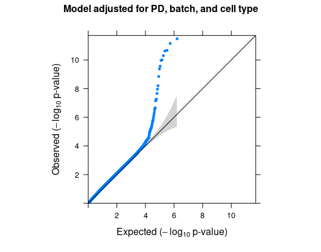

Q-Q plot for updated EWAS model

The majority of p-values follow the expected distribution, while the tail branches off strongly. This is similar to the previous Q-Q plot generated by Will, and demonstrates an appropriate model (mostly null p-values) with an expected strong effect of genotype on DNA methylation.

Despite an association between cell type PC2 and PD status, the VIF calculations indicate low (if any) collinearity, and the bacon results indicate low bias (number should be near zero) and no inflation (number should be near 1, and is exactly 1 here).

## Differential methylation analysis

Will used limma on all EPIC probes passing QC, modeling the data with M-values. I’ll continue with this approach and transform results back to beta values later for plotting and interpretation purposes.

First, as Will did, I’ll apply the updated models to (1) the cross-sex sample, (2) males, (3) females, (4) PD cases, and (5) controls. This permits us to detect whether GRS associations with DNAm are dependent on sex and/or disease status.

```r
# set up meta data
na_row <- !apply(meta_sub[, c("SCORE1_AVG", "age", "sex", "geno_V3", "geno_V4", "geno_V5", "CTP_PC1", "CTP_PC2", "CTP_PC3", "CTP_PC4", "CTP_PC5", "CTP_PC6", "plate", "SentrixPosition_A", "PD")], 1, function(x) any(is.na(x)))
summary(na_row) #no NA's for these covariates
str(meta_sub[,c("SCORE1_AVG", "age", "sex", "geno_V3", "geno_V4", "geno_V5", "CTP_PC1", "CTP_PC2", "CTP_PC3", "CTP_PC4", "CTP_PC5", "CTP_PC6", "plate", "SentrixPosition_A", "PD")]) #checking format again - good

# limma design matrix and linear model fit
design_prs <- model.matrix(~ 1 + SCORE1_AVG + age + sex + geno_V3 + geno_V4 + geno_V5 + CTP_PC1 + CTP_PC2 + CTP_PC3 + CTP_PC4 + CTP_PC5 + CTP_PC6 + plate + SentrixPosition_A + PD, data = meta_sub)
prs_fit <- lmFit(mvals, design_prs)
prs_fit <- eBayes(prs_fit)

# Cases only
design_prs_case <- model.matrix(~ 1 + SCORE1_AVG + age + sex + geno_V3 + geno_V4 + geno_V5 + CTP_PC1 + CTP_PC2 + CTP_PC3 + CTP_PC4 + CTP_PC5 + CTP_PC6 + plate + SentrixPosition_A, data = meta_sub[meta_sub$PD=="1",])
prs_fit_case <- lmFit(mvals[,match(unlist(meta_sub[meta_sub$PD=="1","patient"]), colnames(mvals))], design_prs_case)
prs_fit_case <- eBayes(prs_fit_case)

# Controls only
design_prs_control <- model.matrix(~ 1 + SCORE1_AVG + age + sex + geno_V3 + geno_V4 + geno_V5 + CTP_PC1 + CTP_PC2 + CTP_PC3 + CTP_PC4 + CTP_PC5 + CTP_PC6 + plate + SentrixPosition_A, data = meta_sub[meta_sub$PD=="0",])
prs_fit_control <- lmFit(mvals[,match(unlist(meta_sub[meta_sub$PD=="0","patient"]), colnames(mvals))], design_prs_control)
prs_fit_control <- eBayes(prs_fit_control)

# Males
design_prs_male <- model.matrix(~ 1 + SCORE1_AVG + age + geno_V3 + geno_V4 + geno_V5 + CTP_PC1 + CTP_PC2 + CTP_PC3 + CTP_PC4 + CTP_PC5 + CTP_PC6 + plate + SentrixPosition_A + PD, data = meta_sub[meta_sub$sex=="M",])
prs_fit_male <- lmFit(mvals[,match(unlist(meta_sub[meta_sub$sex=="M","patient"]), colnames(mvals))], design_prs_male)
# Coefficients not estimable: plate6 plate9
# Partial NA coefficients for 803777 probe(s)
prs_fit_male <- eBayes(prs_fit_male)
# Estimation of var.prior failed - set to default value

# Females
design_prs_female <- model.matrix(~ 1 + SCORE1_AVG + age + geno_V3 + geno_V4 + geno_V5 + CTP_PC1 + CTP_PC2 + CTP_PC3 + CTP_PC4 + CTP_PC5 + CTP_PC6 + plate + SentrixPosition_A + PD, data = meta_sub[meta_sub$sex=="F",])
prs_fit_female <- lmFit(mvals[,match(unlist(meta_sub[meta_sub$sex=="F","patient"]), colnames(mvals))], design_prs_female)
prs_fit_female <- eBayes(prs_fit_female)

design_pd <- model.matrix(~ 1 + PD + age + sex + geno_V3 + geno_V4 + geno_V5 + CTP_PC1 + CTP_PC2 + CTP_PC3 + CTP_PC4 + CTP_PC5 + CTP_PC6 + plate + SentrixPosition_A, data = meta_sub)
pd_fit <- lmFit(mvals, design_pd)
pd_fit <- eBayes(pd_fit)
pd_res <- limma::topTable(pd_fit, coef = 2, number = Inf, genelist=rownames(mvals))
prs_res <- limma::topTable(prs_fit, coef = 2, number = Inf, genelist=rownames(mvals))
control_res <- limma::topTable(prs_fit_control, coef = 2, number = Inf, genelist=rownames(mvals))
case_res <- limma::topTable(prs_fit_case, coef = 2, number = Inf, genelist=rownames(mvals))
male_res <- limma::topTable(prs_fit_male, coef = 2, number = Inf, genelist=rownames(mvals))
female_res <- limma::topTable(prs_fit_female, coef = 2, number = Inf, genelist=rownames(mvals))

# save everything
# put limma results in separate csv's and together as one RData object for ease later
save(mvals, file="~/PD_GRS/TERRE_Mvals.RData")
write.csv(meta_sub, file="~/PD_GRS/meta_for_GRS_EWAS.csv", row.names=F)
save(pd_res, prs_res, control_res, case_res, male_res, female_res, file="~/PD_GRS/EWAS_limma_all.RData")
write.csv(pd_res, file="~/PD_GRS/EWAS_PD.csv", row.names=F)
write.csv(prs_res, file="~/PD_GRS/EWAS_GRS_cross_sex.csv", row.names=F)
write.csv(case_res, file="~/PD_GRS/EWAS_GRS_cases.csv", row.names=F)
write.csv(control_res, file="~/PD_GRS/EWAS_GRS_controls.csv", row.names=F)
write.csv(male_res, file="~/PD_GRS/EWAS_GRS_males.csv", row.names=F)
write.csv(female_res, file="~/PD_GRS/EWAS_GRS_females.csv", row.names=F)
```

### Plotting results

For now, I am plotting adjusted delta M-values (model coefficients) to compare with the previous result, and will use the same thresholds reported by Will (delta M > 1.5, padj < 0.05). After, I’ll calculate the delta betas for the same model.

#### Cross-sex GRS EWAS

```r
meta_sub <- read.csv("~/PD_GRS/meta_for_GRS_EWAS.csv")
prs_res <- read.csv("~/PD_GRS/EWAS_GRS_cross_sex.csv")
load("~/PD_GRS/TERRE_Mvals.RData")

# annotate topTable
load("~/kobor_shared_coding_resource/EPIC_fdat.RData")
fdat <- fData_EPIC[match(rownames(mvals), fData_EPIC$TargetID),]
all(fdat$TargetID==rownames(mvals))
colnames(prs_res)[1] <- "TargetID"
prs_res <- left_join(prs_res, fdat, by="TargetID")

# logFC: delta M
# AveExpr: average M
colnames(prs_res)[2:3] <- c("delta_M", "avgM")
write.csv(prs_res, file="~/PD_GRS/EWAS_GRS_cross_sex.csv", row.names=F)

# plot with delta M threshold
summary(prs_res$threshold_M <- (prs_res$adj.P.Val <= 0.05 & abs(prs_res$delta_M)>=1.5)) #27
prs_hits <- prs_res[prs_res$threshold_M==TRUE,]
write.csv(prs_hits, file="~/PD_GRS/EWAS_GRS_cross_sex_hits.csv", row.names=F)

max(prs_res[prs_res$threshold_M==TRUE,"P.Value"]) #1.670565e-06
prs_res$DNAm_change <- "NS"
prs_res[prs_res$threshold_M==TRUE & prs_res$delta_M>0,"DNAm_change"] <- "Increase"
prs_res[prs_res$threshold_M==TRUE & prs_res$delta_M<0,"DNAm_change"] <- "Decrease"
summary(as.factor(prs_res$DNAm_change))
#Decrease Increase       NS
#       9       18   803750

# check gene names of hits
View(prs_hits[,c("TargetID","UCSC_REFGENE_NAME")])
prs_hits$UCSC_REFGENE_NAME
# replace repeated gene names
prs_hits$UCSC_REFGENE_NAME <- as.character(prs_hits$UCSC_REFGENE_NAME)
prs_hits$UCSC_REFGENE_NAME <- c("MAPT","KIAA1267","","KANSL1","ARHGAP27","","","KANSL1","","MGC57346-CRHR1","MAPT",
                               "MAPT","","MAPT","","ARHGAP27","KANSL1","","MAPT","","KANSL1","ALK","MGC57346-CRHR1",
                               "MAPT","SORCS3","NRP2","ARHGAP27")
prs_res_hits <- prs_res[match(prs_hits$TargetID, prs_res$TargetID),]
all(prs_res_hits$TargetID==prs_hits$TargetID)
prs_res_hits$UCSC_REFGENE_NAME <- prs_hits$UCSC_REFGENE_NAME
prs_res_other <- prs_res[-(which(prs_res$TargetID %in% prs_hits$TargetID)),]
prs_res_other$UCSC_REFGENE_NAME <- as.character(prs_res_other$UCSC_REFGENE_NAME)
prs_res <- rbind(prs_res_hits, prs_res_other)
write.csv(prs_res, file="~/PD_GRS/EWAS_GRS_cross_sex.csv", row.names=F)
write.csv(prs_res_hits, file="~/PD_GRS/EWAS_GRS_cross_sex_hits.csv", row.names=F)

max(abs(prs_res$delta_M)) #195.2651
max(-log10(prs_res$P.Value)) #11.95357

png("~/PD_GRS/volcano_GRS_cross_sex_Mvals.png", width=200, height=250)
ggplot(prs_res[,c("delta_M","P.Value","DNAm_change","UCSC_REFGENE_NAME")], aes(x=delta_M, y=-log10(P.Value), colour=DNAm_change)) +
  geom_point(size=1.75) +
  labs(legend.position = "none") +
  xlab("Adjusted Delta M") + ylab("-log10 P-Value") + theme_classic() + scale_color_manual(values=c("black","black","gray70")) + geom_hline(yintercept=-log10(1.670565e-06)) + geom_vline(xintercept=-1.5) + geom_vline(xintercept=1.5) +
    geom_label_repel(data = prs_res[prs_res$threshold==TRUE,c("delta_M","P.Value","DNAm_change","UCSC_REFGENE_NAME")],
            aes(label = UCSC_REFGENE_NAME), size = 4, force = 10, max.overlaps=8) + theme(legend.position="none")+ ylim(c(0,15)) + xlim(c(-200,200))
dev.off()

# Compare with previous result - how many overlap?
SI <- read_xlsx("~/PD_GRS/Table SI.xlsx", skip=2)
SI_cross_sex <- SI[SI$`TERRE Sample`=="Cross-sex",]
length(prs_res_hits$TargetID[prs_res_hits$TargetID %in% SI_cross_sex$Probe]) #25

# join data together to compare effects and p-values from each analysis
SI_sub <- SI_cross_sex[,c("Probe","logFC","BH Adjusted P Value")]
colnames(SI_sub) <- c("TargetID", "delta_M_orig", "adj.P.Val.orig")
combine <- left_join(prs_res_hits, SI_sub, by="TargetID")
combine <- combine[complete.cases(combine$delta_M_orig),]
max(c(combine$delta_M, combine$delta_M_orig)) #195.2651
min(c(combine$delta_M, combine$delta_M_orig)) #-177.9853

png("~/PD_GRS/EWAS_cross_sex_Mval_comparison.png", width=200, height=225)
ggplot(combine, aes(x=delta_M, y=delta_M_orig)) + geom_point() + geom_smooth(method="lm", col="grey") + theme_bw() + xlab("New adjusted delta M") + ylab("Original adjusted delta M") + xlim(c(-200,200)) + ylim(c(-200,200)) + ggtitle("Cross-sex EWAS M-value \ncomparison") + stat_cor(label.y=150)
dev.off()
```

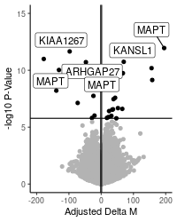

Updated EWAS model

Most of the associations were also found previously, and many are on chromosome 17, mapping to the MAPT gene. This is consistent with Will’s previous findings and demonstrative of the very strong association between the GRS and chr 17 DNA methylation.

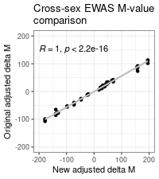

Adjusted delta M-values for the 25 overlapping probes are strongly correlated between the two methods.

#### Cross-sex PD status EWAS

```r
pd_res <- read.csv("~/PD_GRS/EWAS_PD.csv")

# annotate topTable
all(fdat$TargetID==rownames(mvals))
colnames(pd_res)[1] <- "TargetID"
pd_res <- left_join(pd_res, fdat, by="TargetID")

# logFC: delta M
# AveExpr: average M
colnames(pd_res)[2:3] <- c("delta_M", "avgM")

# plot with delta M threshold
summary(pd_res$threshold_M <- (pd_res$adj.P.Val <= 0.05 & abs(pd_res$delta_M)>=1.5)) #none pass threshold
min(pd_res$adj.P.Val) #0.9940453
pd_res$DNAm_change <- "NS"
write.csv(pd_res, file="~/PD_GRS/EWAS_PD.csv", row.names=F)

max(abs(pd_res$delta_M)) #1.526025
max(-log10(pd_res$P.Value)) #5.597638

# with the same plot parameters as above (for comparison)
png("~/PD_GRS/volcano_PD_Mvals.png", width=200, height=250)
ggplot(pd_res[,c("delta_M","P.Value","DNAm_change")], aes(x=delta_M, y=-log10(P.Value), colour=DNAm_change)) +
  geom_point(size=1.75) +
  labs(legend.position = "none") +
  xlab("Adjusted Delta M") + ylab("-log10 P-Value") + theme_classic() + scale_color_manual(values=c("gray70")) + geom_hline(yintercept=-log10(1.7e-06)) + geom_vline(xintercept=-1.5) + geom_vline(xintercept=1.5) + theme(legend.position="none")+ ylim(c(0,15)) + xlim(c(-200,200))
dev.off()

# zoomed in
png("~/PD_GRS/volcano_PD_Mvals_zoom.png", width=200, height=250)
ggplot(pd_res[,c("delta_M","P.Value","DNAm_change")], aes(x=delta_M, y=-log10(P.Value), colour=DNAm_change)) +
  geom_point(size=1.75) +
  labs(legend.position = "none") +
  xlab("Adjusted Delta M") + ylab("-log10 P-Value") + theme_classic() + scale_color_manual(values=c("gray70")) + geom_vline(xintercept=-1.5) + geom_vline(xintercept=1.5) + theme(legend.position="none")+ ylim(c(0,6)) + xlim(c(-2,2))
dev.off()
```

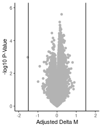

Cross-sex EWAS for PD status

#### Cross-sex GRS EWAS in PD cases

```r
case_res <- read.csv("~/PD_GRS/EWAS_GRS_cases.csv")

# annotate topTable
all(fdat$TargetID==rownames(mvals))
colnames(case_res)[1] <- "TargetID"
case_res <- left_join(case_res, fdat, by="TargetID")

# logFC: delta M
# AveExpr: average M
colnames(case_res)[2:3] <- c("delta_M", "avgM")

# plot with delta M threshold
summary(case_res$threshold_M <- (case_res$adj.P.Val <= 0.05 & abs(case_res$delta_M)>=1.5)) #none
case_res$DNAm_change <- "NS"
write.csv(case_res, file="~/PD_GRS/EWAS_GRS_cases.csv", row.names=F)

max(abs(case_res$delta_M)) #318.9209
max(-log10(case_res$P.Value)) #5.01351

png("~/PD_GRS/volcano_GRS_cases_Mvals.png", width=200, height=250)
ggplot(case_res[,c("delta_M","P.Value","DNAm_change")], aes(x=delta_M, y=-log10(P.Value), colour=DNAm_change)) +
  geom_point(size=1.75) +
  labs(legend.position = "none") +
  xlab("Adjusted Delta M") + ylab("-log10 P-Value") + theme_classic() + scale_color_manual(values=c("gray70")) + geom_hline(yintercept=-log10(1.7e-06)) + geom_vline(xintercept=-1.5) + geom_vline(xintercept=1.5) + theme(legend.position="none")+ ylim(c(0,15)) + xlim(c(-350,350))
dev.off()
```

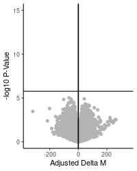

EWAS in PD cases

There are no DNAm changes related to the GRS in PD cases (p-values are not significant, indicating high variability in effect sizes).

#### Cross-sex GRS EWAS in controls

```r
control_res <- read.csv("~/PD_GRS/EWAS_GRS_controls.csv")

# annotate topTable
all(fdat$TargetID==rownames(mvals))
colnames(control_res)[1] <- "TargetID"
control_res <- left_join(control_res, fdat, by="TargetID")

# logFC: delta M
# AveExpr: average M
colnames(control_res)[2:3] <- c("delta_M", "avgM")

# plot with delta M threshold
summary(control_res$threshold_M <- (control_res$adj.P.Val <= 0.05 & abs(control_res$delta_M)>=1.5)) #14
control_hits <- control_res[control_res$threshold_M==TRUE,]
write.csv(control_hits, file="~/PD_GRS/EWAS_GRS_controls_hits.csv", row.names=F)

max(control_res[control_res$threshold_M==TRUE,"P.Value"]) #6.823928e-07
control_res$DNAm_change <- "NS"
control_res[control_res$threshold_M==TRUE & control_res$delta_M>0,"DNAm_change"] <- "Increase"
control_res[control_res$threshold_M==TRUE & control_res$delta_M<0,"DNAm_change"] <- "Decrease"
summary(as.factor(control_res$DNAm_change))
#Decrease Increase       NS
#       6        8   803763

# check gene names of hits
View(control_hits[,c("TargetID","UCSC_REFGENE_NAME")])
control_hits$UCSC_REFGENE_NAME
# replace repeated gene names
control_hits$UCSC_REFGENE_NAME <- as.character(control_hits$UCSC_REFGENE_NAME)
control_hits$UCSC_REFGENE_NAME <- c("", "KANSL1", "ARGHAP27", "KANSL1", "MAPT", "KIAA1267", "", "", "", "MAPT", "MAPT", "SORCSC3", "MGC57346-CRHR1", "MAPT")
control_res_hits <- control_res[match(control_hits$TargetID, control_res$TargetID),]
all(control_res_hits$TargetID==control_hits$TargetID)
control_res_hits$UCSC_REFGENE_NAME <- control_hits$UCSC_REFGENE_NAME
control_res_other <- control_res[-(which(control_res$TargetID %in% control_hits$TargetID)),]
control_res_other$UCSC_REFGENE_NAME <- as.character(control_res_other$UCSC_REFGENE_NAME)
control_res <- rbind(control_res_hits, control_res_other)
write.csv(control_res, file="~/PD_GRS/EWAS_GRS_controls.csv", row.names=F)
write.csv(control_res_hits, file="~/PD_GRS/EWAS_GRS_controls_hits.csv", row.names=F)

max(abs(control_res$delta_M)) #218.4101
max(-log10(control_res$P.Value)) #9.334038

png("~/PD_GRS/volcano_GRS_controls_Mvals.png", width=200, height=250)
ggplot(control_res[,c("delta_M","P.Value","DNAm_change","UCSC_REFGENE_NAME")], aes(x=delta_M, y=-log10(P.Value), colour=DNAm_change)) +
  geom_point(size=1.75) +
  labs(legend.position = "none") +
  xlab("Adjusted Delta M") + ylab("-log10 P-Value") + theme_classic() + scale_color_manual(values=c("black","black","gray70")) + geom_hline(yintercept=-log10(6.823928e-07)) + geom_vline(xintercept=-1.5) + geom_vline(xintercept=1.5) +
    geom_label_repel(data = control_res[control_res$threshold==TRUE,c("delta_M","P.Value","DNAm_change","UCSC_REFGENE_NAME")],
            aes(label = UCSC_REFGENE_NAME), size = 4, force = 10, max.overlaps=6) + theme(legend.position="none")+ ylim(c(0,15)) + xlim(c(-250,250))
dev.off()

# How many overlap with combined case-control sample?
length(control_res_hits$TargetID[control_res_hits$TargetID %in% prs_res_hits$TargetID]) #13

# Look at the one that doesn't overlap
control_res_hits[-which(control_res_hits$TargetID %in% prs_res_hits$TargetID),c("TargetID","UCSC_REFGENE_NAME","UCSC_REFGENE_GROUP","delta_M","adj.P.Val")]
#     TargetID UCSC_REFGENE_NAME                              UCSC_REFGENE_GROUP   delta_M  adj.P.Val
#11 cg00112026              MAPT 5'UTR;5'UTR;5'UTR;5'UTR;5'UTR;5'UTR;5'UTR;5'UTR -40.04757 0.01990275

# Compare effect size with combined sample
# join data together to compare effects and p-values from each analysis
prs_sub <- prs_res_hits[,c("TargetID","delta_M","adj.P.Val")]
colnames(prs_sub) <- c("TargetID", "delta_M_combined", "adj.P.Val.combined")
combine <- left_join(control_res_hits, prs_sub, by="TargetID")
combine <- combine[complete.cases(combine$delta_M_combined),]
max(c(combine$delta_M, combine$delta_M_combined)) #218.4101
min(c(combine$delta_M, combine$delta_M_combined)) #-211.3666

png("~/PD_GRS/EWAS_control_vs_combined_Mvals.png", width=200, height=250)
ggplot(combine, aes(x=delta_M, y=delta_M_combined)) + geom_point() + geom_smooth(method="lm", col="grey") + theme_bw() + xlab("Controls adjusted delta M") + ylab("Combined case-control adjusted delta M") + xlim(c(-250,250)) + ylim(c(-250,250)) + ggtitle("Cross-sex EWAS M-value \ncomparison \n(controls vs. combined)") + stat_cor(label.y=150)
dev.off()
```

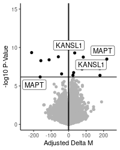

EWAS in controls

14 probes are associated with the GRS in controls, 13 of which also appeared in the combined case-control sample.

[figure not shown]

#### Females GRS EWAS

```r
female_res <- read.csv("~/PD_GRS/EWAS_GRS_females.csv")

# annotate topTable
colnames(female_res)[1] <- "TargetID"
female_res <- left_join(female_res, fdat, by="TargetID")

# logFC: delta M
# AveExpr: average M
colnames(female_res)[2:3] <- c("delta_M", "avgM")
write.csv(female_res, file="~/PD_GRS/EWAS_GRS_females.csv", row.names=F)

# plot with delta M threshold
summary(female_res$threshold_M <- (female_res$adj.P.Val <= 0.05 & abs(female_res$delta_M)>=1.5)) #no hits
min(female_res$adj.P.Val) #0.3603336
female_res$DNAm_change <- "NS"
write.csv(female_res, file="~/PD_GRS/EWAS_GRS_females.csv", row.names=F)

max(abs(female_res$delta_M)) #238.3878
max(-log10(female_res$P.Value)) #5.97757

png("~/PD_GRS/volcano_GRS_females_Mvals.png", width=200, height=250)
ggplot(female_res[,c("delta_M","P.Value","DNAm_change")], aes(x=delta_M, y=-log10(P.Value), colour=DNAm_change)) +
  geom_point(size=1.75) +
  labs(legend.position = "none") +
  xlab("Adjusted Delta M") + ylab("-log10 P-Value") + theme_classic() + scale_color_manual(values=c("gray70")) + geom_hline(yintercept=-log10(1.7e-06)) + geom_vline(xintercept=-1.5) + geom_vline(xintercept=1.5) + theme(legend.position="none")+ ylim(c(0,15)) + xlim(c(-250,250))
dev.off()

# Compare with previous result
# Check effect size of previously significant probes with effect size in the new analysis
SI_female <- SI[SI$`TERRE Sample`=="Female",]

# join data together to compare effects and p-values from each analysis
SI_sub <- SI_female[,c("Probe","logFC","BH Adjusted P Value")]
colnames(SI_sub) <- c("TargetID", "delta_M_orig", "adj.P.Val.orig")
female_res_sub <- female_res[female_res$TargetID %in% SI_sub$TargetID,] #41 probes
combine <- left_join(female_res_sub, SI_sub, by="TargetID")
combine <- combine[complete.cases(combine$delta_M_orig),]
max(c(combine$delta_M, combine$delta_M_orig)) #185.3679
min(c(combine$delta_M, combine$delta_M_orig)) #-186.6422

# M-values plot
png("~/PD_GRS/EWAS_female_Mval_comparison.png", width=200, height=225)
ggplot(combine, aes(x=delta_M, y=delta_M_orig)) + geom_point(col="lightpink4") + geom_smooth(method="lm", col="grey") + theme_bw() + xlab("New adjusted delta M") + ylab("Original adjusted delta M") + xlim(c(-200,200)) + ylim(c(-200,200)) + ggtitle("Female EWAS M-value \ncomparison") + stat_cor(label.y=150)
dev.off()

# P-values plot
png("~/PD_GRS/EWAS_female_pval_comparison.png", width=200, height=225)
ggplot(combine, aes(x=adj.P.Val, y=adj.P.Val.orig)) + geom_point(col="lightpink4") + geom_smooth(method="lm", col="grey") + theme_bw() + xlab("New adjusted p-value") + ylab("Original adjusted p-value") + xlim(c(0,1)) + ylim(c(0,1)) + ggtitle("Female EWAS p-value \ncomparison") + stat_cor(label.y=0.8)
dev.off()
```

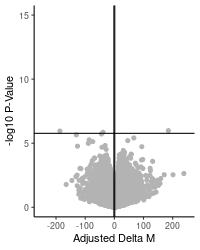

Updated female EWAS model

Nothing reaches statistical significance for females when batch, cell type, and PD status are adjusted for.

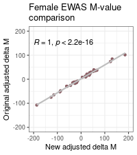

Adjusted delta M-values for the 41 probes originally discovered in the females EWAS are strongly correlated between the two methods.

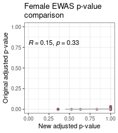

Adjusted p-values for the 41 probes originally discovered in the females EWAS are all > 0.3 in the new EWAS.

#### Males GRS EWAS

```r
male_res <- read.csv("~/PD_GRS/EWAS_GRS_males.csv")

# annotate topTable
colnames(male_res)[1] <- "TargetID"
male_res <- left_join(male_res, fdat, by="TargetID")

# logFC: delta M
# AveExpr: average M
colnames(male_res)[2:3] <- c("delta_M", "avgM")

# plot with delta M threshold
summary(male_res$threshold_M <- (male_res$adj.P.Val <= 0.05 & abs(male_res$delta_M)>=1.5)) #no hits
min(male_res$adj.P.Val) #0.1729346
min(male_res$P.Value) #2.151525e-07
male_res$DNAm_change <- "NS"
write.csv(male_res, file="~/PD_GRS/EWAS_GRS_males.csv", row.names=F)

max(abs(male_res$delta_M)) #187.229
max(-log10(male_res$P.Value)) #6.667254

png("~/PD_GRS/volcano_GRS_males_Mvals.png", width=200, height=250)
ggplot(male_res[,c("delta_M","P.Value","DNAm_change")], aes(x=delta_M, y=-log10(P.Value), colour=DNAm_change)) +
  geom_point(size=1.75) +
  labs(legend.position = "none") +
  xlab("Adjusted Delta M") + ylab("-log10 P-Value") + theme_classic() + scale_color_manual(values=c("gray70")) + geom_hline(yintercept=-log10(2.2e-07)) + geom_vline(xintercept=-1.5) + geom_vline(xintercept=1.5) + theme(legend.position="none")+ ylim(c(0,15)) + xlim(c(-250,250))
dev.off()

# Compare with previous result
# Check effect size of previously significant probes with effect size in the new analysis
SI_male <- SI[SI$`TERRE Sample`=="Male",]

# join data together to compare effects and p-values from each analysis
SI_sub <- SI_male[,c("Probe","logFC","BH Adjusted P Value")]
colnames(SI_sub) <- c("TargetID", "delta_M_orig", "adj.P.Val.orig")
male_res_sub <- male_res[male_res$TargetID %in% SI_sub$TargetID,] #59 probes
combine <- left_join(male_res_sub, SI_sub, by="TargetID")
combine <- combine[complete.cases(combine$delta_M_orig),]
max(c(combine$delta_M, combine$delta_M_orig)) #187.229
min(c(combine$delta_M, combine$delta_M_orig)) #-159.8757

# M-values plot
png("~/PD_GRS/EWAS_male_Mval_comparison.png", width=200, height=225)
ggplot(combine, aes(x=delta_M, y=delta_M_orig)) + geom_point(col="lightsteelblue4") + geom_smooth(method="lm", col="grey") + theme_bw() + xlab("New adjusted delta M") + ylab("Original adjusted delta M") + xlim(c(-200,200)) + ylim(c(-200,200)) + ggtitle("Male EWAS M-value \ncomparison") + stat_cor(label.y=150)
dev.off()

# P-values plot
png("~/PD_GRS/EWAS_male_pval_comparison.png", width=200, height=225)
ggplot(combine, aes(x=adj.P.Val, y=adj.P.Val.orig)) + geom_point(col="lightsteelblue4") + geom_smooth(method="lm", col="grey") + theme_bw() + xlab("New adjusted p-value") + ylab("Original adjusted p-value") + xlim(c(0,1)) + ylim(c(0,1)) + ggtitle("Male EWAS p-value \ncomparison") + stat_cor(label.y=0.8)
dev.off()
```

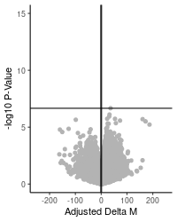

Updated male EWAS model

Nothing reaches statistical significance for males when batch, cell type, and PD status are adjusted for.

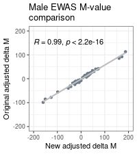

Adjusted delta M-values for the 59 probes originally discovered in the males EWAS are strongly correlated between the two methods.

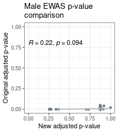

Adjusted p-values for the 59 probes originally discovered in the males EWAS are all > 0.2 in the new EWAS.

## Summary and next steps

In the EWAS models adjusted for batch, cell type, and disease status, some of the same hits show up in cross-sex analysis either with combined cases and controls (25 probes) or controls only (13 probes). These include the MAPT and KANSL1 loci which had very strong effect sizes. In sex-stratified analyses, nothing passes adjusted p-value cutoffs. The reduced number of hits likely means some probes initially discovered were associated with disease status, batch, or cell type.

Sample breakdown:

218 total

71 PD cases

147 controls

100 females

118 males

It is possible the sample size is too small in the sex-stratified and case-only analyses to detect effects. This can be checked with permutations and/or data reduction (e.g. subsetting to variable probes).